# **COVID 19 Lung Damage Detection using Convolutional Neural Networks and Data Augmentation**

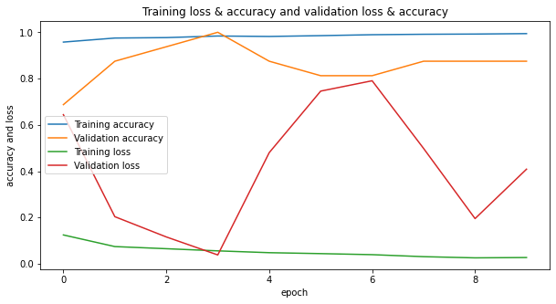

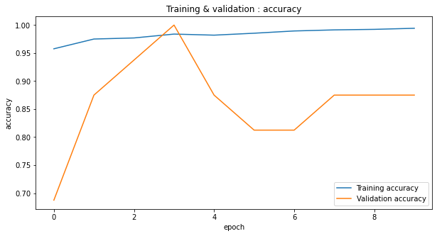

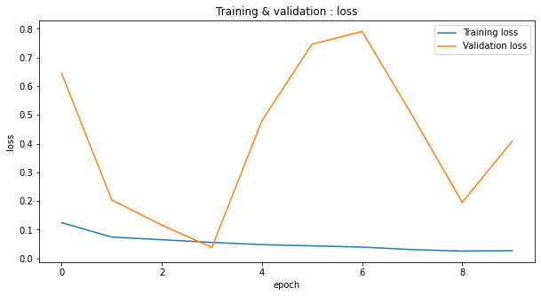

```python
# calling user defined function for visualization
graph(hist)
graphacc(hist)
graphloss(hist)
```

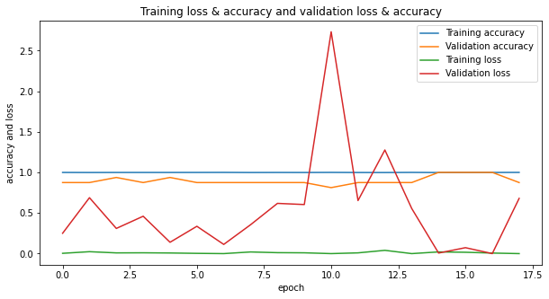

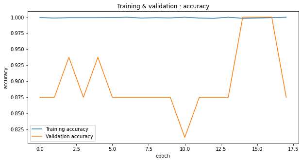

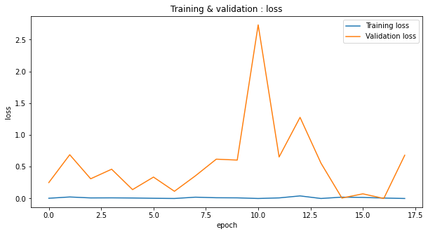

```python
#epoch 18
hist=model.fit_generator(generator=train_dataset_TLM,validation_data= val_dataset_TLM,epochs=18)
model.save('vggclf.h5')
graph(hist)
graphacc(hist)
graphloss(hist)
```

```python
#evaluating the model for testing data..
test_loss,test_acc=model.evaluate(test_dataset_TLM)
print("Accuracy of the model is - " , test_acc*100 , "%")
```

```
Accuracy of the model is -  73.87820482254028 %
```

- **Changing Optimizer and increasing epochs**

```python
model.compile(loss='binary_crossentropy',
              optimizer='Adam',
              metrics=['accuracy'] )
```

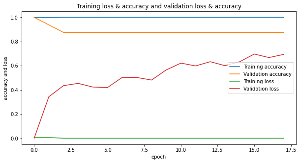

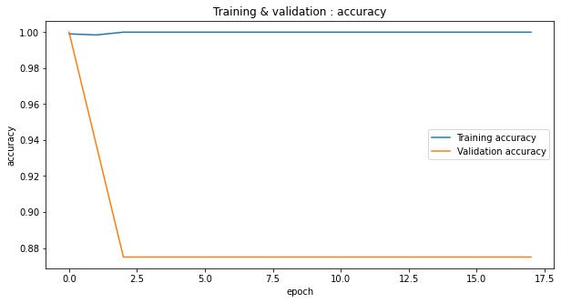

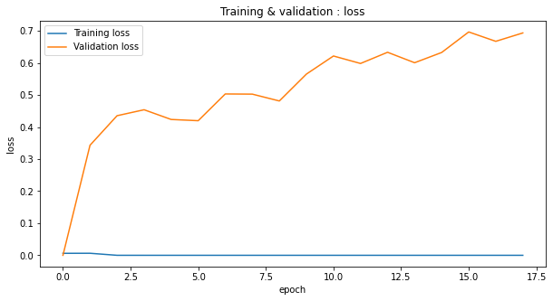

```python
#epoch 18
hist=model.fit_generator(generator=train_dataset_TLM,validation_data= val_dataset_TLM,epochs=18)
model.save('vggclf.h5')

# calling user defined function for visualization
graph(hist)
graphacc(hist)
graphloss(hist)
```

```python
#evaluating the model for testing data..
test_loss,test_acc=model.evaluate(test_dataset_TLM)
print("Accuracy of the model is - " , test_acc*100 , "%")
```

```
Accuracy of the model is -  75.0 %
```

# **VGG19**

[figure not shown]

```python
train = ImageDataGenerator(rescale=1/255)
val = ImageDataGenerator(rescale=1/255)
test = ImageDataGenerator(rescale=1/255)

train_dataset = train.flow_from_directory('/content/drive/MyDrive/Kaggle/chest_xray/chest_xray/train',
                                          target_size=(224,244),
                                          #batch_size=3,
                                          class_mode='binary') # We are having only 2 output classes in dataset so we are using 'Binary' class mode
val_dataset = val.flow_from_directory('/content/drive/MyDrive/Kaggle/chest_xray/chest_xray/val',
                                          target_size=(224,224),
                                          #batch_size=3,
                                          class_mode='binary')
test_dataset = test.flow_from_directory('/content/drive/MyDrive/Kaggle/chest_xray/chest_xray/test',
                                          target_size=(224,224),
                                          #batch_size=3,
                                          class_mode='binary')
```

```
Found 5216 images belonging to 2 classes.
Found 16 images belonging to 2 classes.
Found 624 images belonging to 2 classes.
```

```python
VGG19 = keras.applications.vgg19.VGG19(input_shape=(224,224,3), include_top=False, weights='imagenet')
VGG19.trainable=False
```

```
Downloading data from https://storage.googleapis.com/tensorflow/keras-applications/vgg19/vgg19_weights_tf_dim_ordering_tf_kernels_notop.h5
```

```python
VGG19.summary()
```

[output not shown]

```python
model= keras.Sequential([
                         VGG19,
                         keras.layers.Flatten(),
                         #keras.layers.Dense(units=256,activation='relu'),
                         #keras.layers.Dense(units=256,activation="relu"),
                         #keras.layers.Dense(units=256,activation='relu'),
                         #keras.layers.Dense(units=256,activation="relu"),
                         keras.layers.Dense(units=1,activation="sigmoid")
])
```

```python
model.compile(loss='binary_crossentropy',
              #optimizer=RMSprop(lr=0.001),
              metrics=['accuracy'] )
model.summary()
```

```
Model: "sequential_8"
_________________________________________________________________
Layer (type)                 Output Shape              Param #
=================================================================
vgg19 (Functional)           (None, 7, 7, 512)         20024384
_________________________________________________________________
flatten_8 (Flatten)          (None, 25088)             0
_________________________________________________________________
dense_26 (Dense)             (None, 1)                 25089
=================================================================
Total params: 20,049,473
Trainable params: 25,089
Non-trainable params: 20,024,384
_________________________________________________________________
```

```python
#epoch 10
from datetime import datetime
start=datetime.now()
hist=model.fit_generator(generator=train_dataset,validation_data= val_dataset,epochs=10)
model.save('vgg19clf.h5')
duration=datetime.now()-start
print("Time taken to fit  VGG19 Model : ", duration)
```

```
Time taken to fit  VGG19 Model :  0:09:41.138743
```

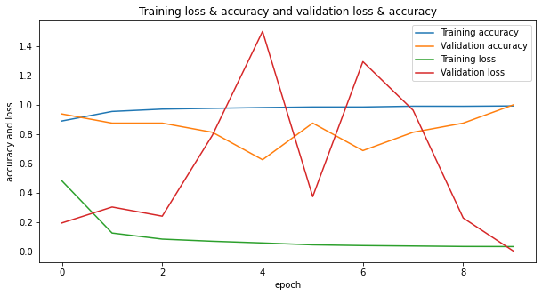

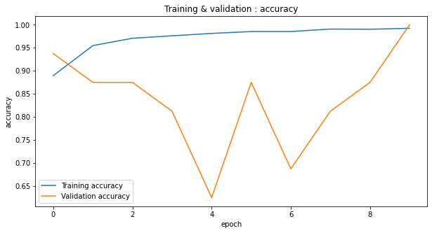

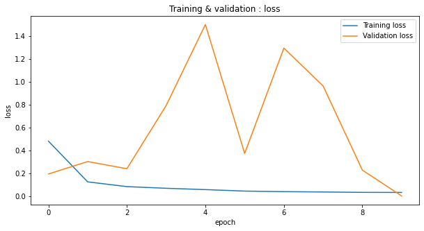

```python
# calling user defined function for visualization
graph(hist)
graphacc(hist)
graphloss(hist)
```

```python
#evaluating the model for testing data..
test_loss,test_acc=model.evaluate(test_dataset_TLM)
print("Accuracy of the model is - " , test_acc*100 , "%")
```

```
Accuracy of the model is -  85.09615659713745 %
```

# **Resnet 50**

[figure not shown]

```python
train = ImageDataGenerator(rescale=1/255)
val = ImageDataGenerator(rescale=1/255)
test = ImageDataGenerator(rescale=1/255)

#TLM: Transfer learning Models
train_dataset_TLM = train.flow_from_directory('/content/drive/MyDrive/Kaggle/chest_xray/chest_xray/train',
                                          target_size=(224,224),
                                          batch_size=3,
                                          class_mode='binary')
val_dataset_TLM = val.flow_from_directory('/content/drive/MyDrive/Kaggle/chest_xray/chest_xray/val',
                                          target_size=(224,224),
                                          batch_size=3,
                                          class_mode='binary')
test_dataset_TLM = test.flow_from_directory('/content/drive/MyDrive/Kaggle/chest_xray/chest_xray/test',
                                          target_size=(224,224),
                                          batch_size=3,
                                          class_mode='binary')
```

```
Found 5216 images belonging to 2 classes.
Found 16 images belonging to 2 classes.
Found 624 images belonging to 2 classes.
```

```python
resnet50 = keras.applications.ResNet50()
resnet50.trainable=False
```

```python
model= keras.Sequential([
                         resnet50,
                         keras.layers.Flatten(),
                         keras.layers.Dense(units=256,activation='relu'),
                         keras.layers.Dense(units=256,activation="relu"),
                         keras.layers.Dense(units=1,activation="sigmoid")
])
```

```python
model.compile(loss='binary_crossentropy',
              optimizer=RMSprop(lr=0.01),
              metrics=['accuracy'] )
model.summary()
```

```
Model: "sequential_15"
_________________________________________________________________
Layer (type)                 Output Shape              Param #
=================================================================
resnet50 (Functional)        (None, 1000)              25636712
_________________________________________________________________
flatten_17 (Flatten)         (None, 1000)              0
_________________________________________________________________
dense_31 (Dense)             (None, 256)               256256
_________________________________________________________________
dense_32 (Dense)             (None, 256)               65792
_________________________________________________________________
dense_33 (Dense)             (None, 1)                 257
=================================================================
Total params: 25,959,017
Trainable params: 322,305
Non-trainable params: 25,636,712
_________________________________________________________________
```

```python
#epoch 10
hist=model.fit_generator(generator=train_dataset_TLM,validation_data= val_dataset_TLM,epochs=10)
model.save('resnet50.h5')
```

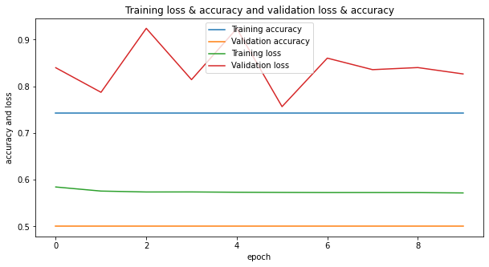

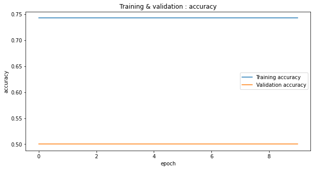

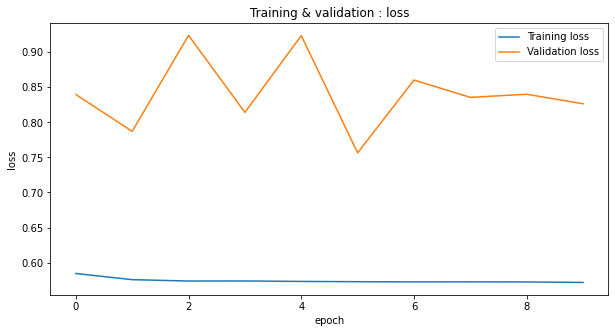

```python
# calling user defined function for visualization
graph(hist)
graphacc(hist)
graphloss(hist)
```

```python
#evaluating the model for testing data..
test_loss,test_acc=model.evaluate(test_dataset_TLM)
print("Accuracy of the model is - " , test_acc*100 , "%")
```

```
Accuracy of the model is -  62.5 %
```

# **Resnet101**

[figure not shown]

```python
train = ImageDataGenerator(rescale=1/255)
val = ImageDataGenerator(rescale=1/255)
test = ImageDataGenerator(rescale=1/255)

#TLM: Transfer learning Models
train_dataset_TLM = train.flow_from_directory('/content/drive/MyDrive/Kaggle/chest_xray/chest_xray/train',
                                          target_size=(224,224),
                                          batch_size=3,
                                          class_mode='binary')
val_dataset_TLM = val.flow_from_directory('/content/drive/MyDrive/Kaggle/chest_xray/chest_xray/val',
                                          target_size=(224,224),
                                          batch_size=3,
                                          class_mode='binary')
test_dataset_TLM = test.flow_from_directory('/content/drive/MyDrive/Kaggle/chest_xray/chest_xray/test',
                                          target_size=(224,224),
                                          batch_size=3,
                                          class_mode='binary')
```

```
Found 5216 images belonging to 2 classes.
Found 16 images belonging to 2 classes.
Found 624 images belonging to 2 classes.
```

```python
resnet101 = keras.applications.ResNet101()
resnet101.trainable=False
```

```
Downloading data from https://storage.googleapis.com/tensorflow/keras-applications/resnet/resnet101_weights_tf_dim_ordering_tf_kernels.h5
```

```python
model= keras.Sequential([
                         resnet101,
                         keras.layers.Flatten(),
                         keras.layers.Dense(units=256,activation='relu'),
                         keras.layers.Dense(units=256,activation="relu"),
                         keras.layers.Dense(units=1,activation="sigmoid")
])
```

```python
model.compile(loss='binary_crossentropy',
              optimizer=RMSprop(lr=0.1),
              metrics=['accuracy'] )
model.summary()
```

```
Model: "sequential_16"
_________________________________________________________________
Layer (type)                 Output Shape              Param #
=================================================================
resnet101 (Functional)       (None, 1000)              44707176
_________________________________________________________________
flatten_18 (Flatten)         (None, 1000)              0
_________________________________________________________________
dense_34 (Dense)             (None, 256)               256256
_________________________________________________________________
dense_35 (Dense)             (None, 256)               65792
_________________________________________________________________
dense_36 (Dense)             (None, 1)                 257
=================================================================
Total params: 45,029,481
Trainable params: 322,305
Non-trainable params: 44,707,176
_________________________________________________________________
```

```python
#epoch 10
from datetime import datetime
start=datetime.now()

hist=model.fit_generator(generator=train_dataset_TLM,validation_data= val_dataset_TLM,epochs=10)
model.save('restnet101.h5')

duration = datetime.now() - start
print("Training completed in time: ", duration)
```

[output not shown]

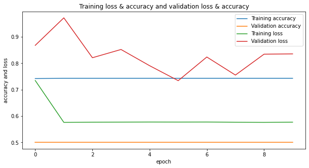

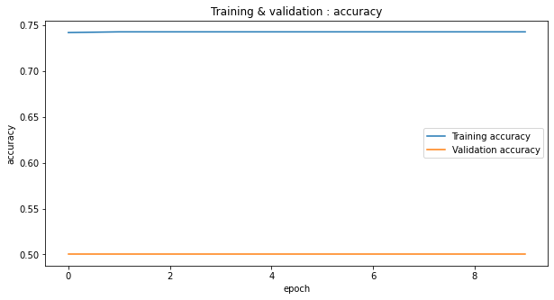

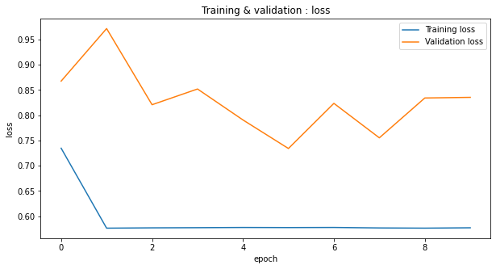

```python
# calling user defined function for visualization
graph(hist)
graphacc(hist)
graphloss(hist)
```

```python
#evaluating the model for testing data..
test_loss,test_acc=model.evaluate(test_dataset_TLM)
print("Accuracy of the model is - " , test_acc*100 , "%")
```

```
Accuracy of the model is -  62.5 %
```

# **Resnet152**

[figure not shown]

```python
train = ImageDataGenerator(rescale=1/255)
val = ImageDataGenerator(rescale=1/255)
test = ImageDataGenerator(rescale=1/255)

#TLM: Transfer learning Models
train_dataset_TLM = train.flow_from_directory('/content/drive/MyDrive/Kaggle/chest_xray/chest_xray/train',
                                          target_size=(224,224),
                                          batch_size=3,
                                          class_mode='binary')
val_dataset_TLM = val.flow_from_directory('/content/drive/MyDrive/Kaggle/chest_xray/chest_xray/val',
                                          target_size=(224,224),
                                          batch_size=3,
                                          class_mode='binary')
test_dataset_TLM = test.flow_from_directory('/content/drive/MyDrive/Kaggle/chest_xray/chest_xray/test',
                                          target_size=(224,224),
                                          batch_size=3,
                                          class_mode='binary')
```

```
Found 5216 images belonging to 2 classes.
Found 16 images belonging to 2 classes.
Found 624 images belonging to 2 classes.
```

```python
resnet152 = keras.applications.ResNet152()
resnet152.trainable=False
```

```
Downloading data from https://storage.googleapis.com/tensorflow/keras-applications/resnet/resnet152_weights_tf_dim_ordering_tf_kernels.h5
```

```python
model= keras.Sequential([
                         resnet152,
                         keras.layers.Flatten(),
                         keras.layers.Dense(units=256,activation='relu'),
                         keras.layers.Dense(units=256,activation="relu"),
                         keras.layers.Dense(units=1,activation="sigmoid")
])
```

```python
model.compile(loss='binary_crossentropy',
              optimizer=RMSprop(lr=0.1),
              metrics=['accuracy'] )
model.summary()
```

```
Model: "sequential_17"
_________________________________________________________________
Layer (type)                 Output Shape              Param #
=================================================================
resnet152 (Functional)       (None, 1000)              60419944
_________________________________________________________________
flatten_19 (Flatten)         (None, 1000)              0
_________________________________________________________________
dense_37 (Dense)             (None, 256)               256256
_________________________________________________________________
dense_38 (Dense)             (None, 256)               65792
_________________________________________________________________
dense_39 (Dense)             (None, 1)                 257
=================================================================
Total params: 60,742,249
Trainable params: 322,305
Non-trainable params: 60,419,944
_________________________________________________________________
```

```python
#epoch 10
from datetime import datetime
start=datetime.now()

hist=model.fit_generator(generator=train_dataset_TLM,validation_data= val_dataset_TLM,epochs=10)
model.save('restnet152.h5')

duration = datetime.now() - start
print("Training completed in time: ", duration)
```

```
Training completed in time:  0:13:58.308638
```

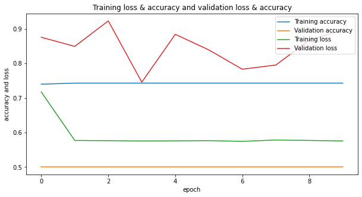

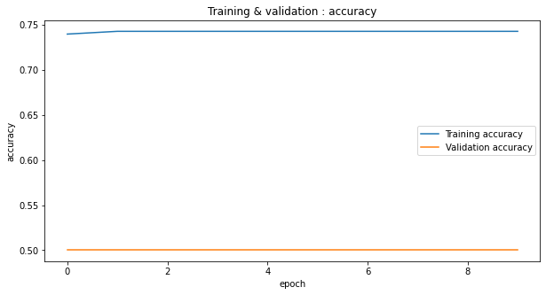

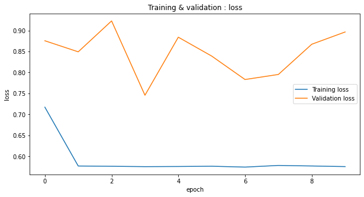

```python
# calling user defined function for visualization
graph(hist)
graphacc(hist)
graphloss(hist)
```

```python
#evaluating the model for testing data..
test_loss,test_acc=model.evaluate(test_dataset_TLM)
print("Accuracy of the model is - " , test_acc*100 , "%")
```

```
Accuracy of the model is -  62.5 %
```

**After applying Transfer learning models to `X-ray images of Lungs` these are the results given below :**

1. VGG16 (Method1)
- Train Accuracy : 73%
- Validation Accuracy : 50%
- Test Accuracy : 62%

  VGG16(Method2)
- Train Accuracy : 100%
- Validation Accuracy : 87%
- Test Accuracy : 75%
1. VGG19
- Train Accuracy : 99%
- Validation Accuracy : 100%
- Test Accuracy : 85%
1. Resnet50
- Train Accuracy : 73%
- Validation Accuracy : 50%
- Test Accuracy : 62%
1. Resnet101
- Train Accuracy : 74%
- Validation Accuracy : 50%
- Test Accuracy : 62%
1. Resnet152
- Train Accuracy : 74%
- Validation Accuracy : 50%
- Test Accuracy : 62%

From the above experiment I've observed that:

**Model :** VGG19 Transfer Learning Model

**Optimizer :** RMSprop,

**Epochs :** 10

Building a Model with the combination of above parameters for **`X-ray images of Lungs`** DataSet Model giving **`99%`** Accuracy in Training and **`85%`** Accuracy in Testing

# Predicting with VGG19 Model

```python
model.predict_classes(val_dataset)
```

```
array([[0],
       [1],
       [1],
       [1],
       [0],
       [1],
       [1],
       [1],
       [0],
       [0],
       [0],
       [1],
       [0],
       [0],
       [1],
       [0]], dtype=int32)
```

```python
val_dataset.classes
```

```
array([0, 0, 0, 0, 0, 0, 0, 0, 1, 1, 1, 1, 1, 1, 1, 1], dtype=int32)
```

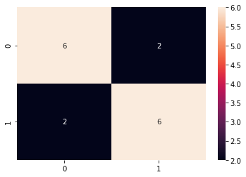

```python
sns.heatmap(confusion_matrix(model.predict_classes(val_dataset),val_dataset.classes),annot=True)
```

- From 16 X-ray Samples VGG19 Model predicting 12 correct Samples